# Assignment Pre-Series04-Python

Authors

Jennifer Houmard

Vidusha Thebuwana

Tuba Tuba

Published

October 12, 2026

**GitHub Repository:** Pre-Series04-Python

```python
import numpy as np
import matplotlib.pyplot as plt
import plotly.graph_objects as go
```

# 1 Group Workflow

To keep the group work clear and efficient, one student first created the GitHub repository and set up the Quarto document structure. The main sections and subheadings were prepared in advance to guide the team on what content needed to be included and how the final report should be organized.

The individual Quarto documents were then distributed among the group members. Each student worked on their assigned section using a separate Git branch. Once a section was completed, it was reviewed by the group and then merged into `main`.

The master Quarto document combines all completed sections into the final report.

| Student | Quarto Document |
| --- | --- |
| Student 1 | `01_generate_known_signal.qmd` |
| Student 2 | `02_time_derivative.qmd` |
| Student 3 | `03_tangential_speed.qmd` and `04_interactive_plot.qmd` |

## 1.1 Repository Structure

```
Pre-Series04-Python/
│
├── Pre-Series04-Python.qmd
├── Pre-Series04-Python.html
│
├── README.md
├── .gitignore
├── LICENSE
│
└── sections/
    ├── 01_generate_known_signal.qmd
    ├── 02_time_derivative.qmd
    ├── 03_tangential_speed.qmd
    └── 04_interactive_plot.qmd
```

## 1.2 Branching Structure

- main
- 01_generate_known_signal
- 02_time_derivative
- 03_tangential_speed
- 04_interactive_plot

# 2 Generate a known signal

## 2.1 Sinusoid Equation

Objective: to define the mathematical signal that will be generated in Python. We first describe a 1 Hz sinusoidal signal with an amplitude of 1 and no phase shift. This provides the reference signal for the x-axis before introducing phase shifts for the y- and z-axes.

A sinusoidal signal can be described by:
$$s(t) = A \sin(2\pi f t + \phi)$$

where:

- $A$ is the amplitude,
- $f$ is the frequency in Hz,
- $t$ is time in seconds,
- $\phi$ is the phase shift in radians.

For this signal:
$$A = 1, \qquad f = 1 \text{ Hz}, \qquad \phi = 0$$

Therefore, the sinusoid along the x-axis is:

$$x(t) = \sin(2\pi t)$$

A frequency of 1 Hz means that the signal completes one full cycle every second. Therefore, over 3 seconds, the signal completes three cycles.

## 2.2 Time Vector and Signal

Objective: to create the time values at which the sinusoidal signal will be calculated. The provided example uses 100 samples over a duration of 3 seconds and requires the time vector to be a column vector with shape `(100, 1)`.

> **Note:** The brief gives values that do not match. At 100 Hz for 3 seconds, there should be 300 samples, not 1000. The example also shows 100 samples, so we use 100 samples to match the expected output.

### 2.2.1 Time Vector

First, we define the duration and number of samples:

```python
duration = 3  # Total duration of the signal in seconds

n_samples = 100  # Number of samples used in the provided example
```

Then we create 100 equally spaced time values between 0 and 3 seconds:

```python
time = np.linspace(0, duration, n_samples)  # Create the time values from 0 to 3 seconds

print(time.shape)
```

```
(100,)
```

Convert the time vector into a column vector: we need 100 rows and 1 column since np.linspace initially creates a one dimensional array

```python
time = time.reshape(-1, 1)  # Convert the time vector into a column vector

print(time.shape)  # Check the shape of the time vector
```

```
(100, 1)
```

## 2.3 Signal Visualization

### 2.3.1 Create the x, y, and z Signals

Objective: to use the `time` vector created above to create a 3D sinusoidal signal. Each dimension has the same amplitude and frequency, but the phase is shifted by $\pi/4$ from one axis to the next.

We first define the amplitude, frequency, and phase shift:

```python
amplitude = 1  # Set the amplitude of each sinusoidal signal to 1

frequency = 1  # Set the frequency of each sinusoidal signal to 1 Hz

phase_shift = np.pi / 4  # Set the phase shift between each axis to pi/4 radians
```

Now we create the 3 signals x, y, and z:

```python
x = amplitude * np.sin(2 * np.pi * frequency * time)  # Create the x signal with no phase shift

y = amplitude * np.sin(2 * np.pi * frequency * time + phase_shift)  # Shift y by pi/4 relative to x

z = amplitude * np.sin(2 * np.pi * frequency * time + 2 * phase_shift)  # Shift z by another pi/4 relative to y
```

### 2.3.2 Combine the Signals into a 2D Array

Objective: to combine the separate x, y, and z signals into one 2D NumPy array.

Each signal currently has the shape:

```
(100, 1)
```

We want the final signal array to contain: - x in the first column, - y in the second column, - z in the third column.

```
(100, 3)
```

```python
signal = np.hstack((x, y, z))  # Combine x, y, and z horizontally into one 2D array
# hstack = horizontal stack

print(signal.shape)  # Print the shape of the combined signal array
```

```
(100, 3)
```

### 2.3.3 2D Plot

Objective: to visualize how the x, y, and z sinusoidal signals change over time.

Plotting the three signals on the same graph allows us to clearly see that they have the same amplitude and frequency, while being shifted in phase relative to each other.

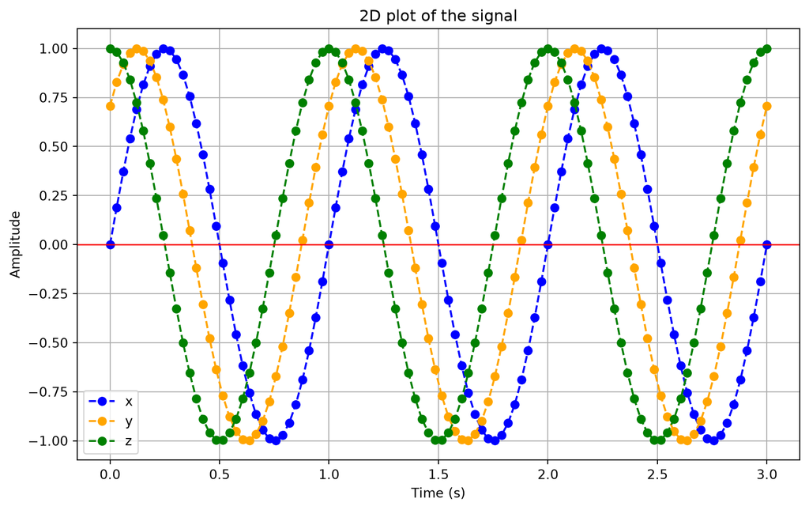

```
(100, 1)
(100, 3)
phase_shift = 0.25 pi
```

```python
plt.figure(figsize=(10, 6))  # Create a new figure and define its size

plt.plot(time[:, 0], signal[:, 0], marker="o", linestyle="--", label="x", color = "blue")  # Plot the x signal against time

plt.plot(time[:, 0], signal[:, 1], marker="o", linestyle="--", label="y", color = "orange")  # Plot the y signal against time

plt.plot(time[:, 0], signal[:, 2], marker="o", linestyle="--", label="z", color = "green")  # Plot the z signal against time

plt.axhline(0, color="red", linewidth=1)  # Add a horizontal reference line at zero

plt.title("2D plot of the signal")
plt.xlabel("Time (s)")  # Label the horizontal axis
plt.ylabel("Amplitude")  # Label the vertical axis

plt.legend()  # Identify the x, y, and z signals
plt.grid()  # Add a grid to make the plot easier to read

plt.show()  # Display the completed plot

print(time.shape)  # Check the shape of the time vector
print(signal.shape)  # Print the shape of the combined signal array
print(f"phase_shift = {phase_shift / np.pi:.2f} pi")  # Express the phase shift as a multiple of pi
```

### 2.3.4 3D Plot

Objective: to represent the signal in three dimensions using the x, y, and z coordinates.

Unlike the 2D plot, which shows how each signal changes over time, the 3D plot shows the geometric trajectory formed by the three sinusoidal dimensions together.

Each sample is represented by one point in 3D space:

- x gives the position on the x-axis,
- y gives the position on the y-axis,
- z gives the position on the z-axis.

This allows us to visualize the overall shape created by the phase-shifted sinusoidal signals.

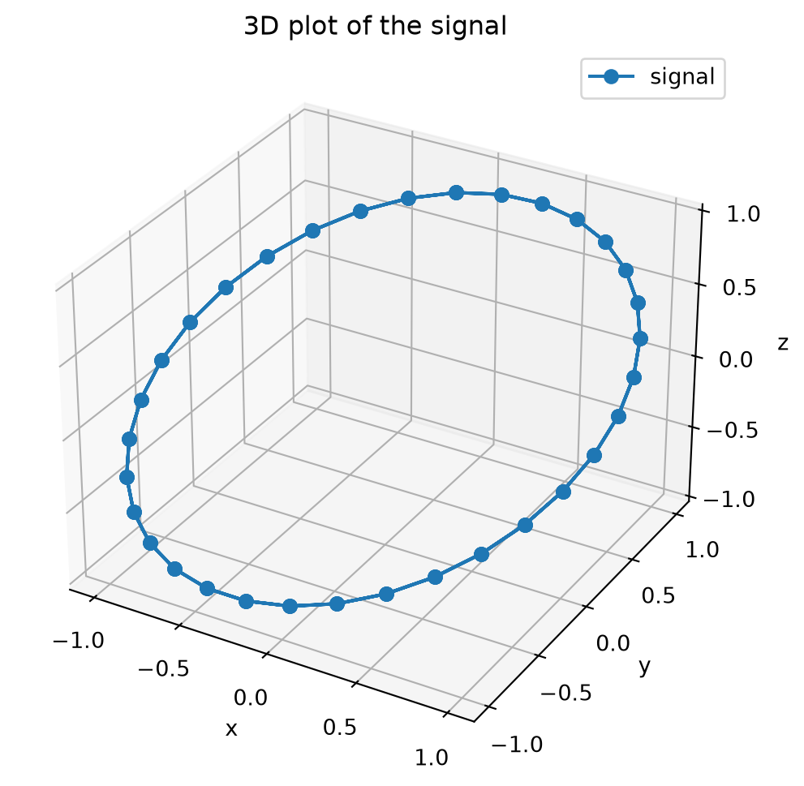

```python
plt.figure(figsize=(8, 6))  # Create a new figure

ax = plt.axes(projection="3d")  # Create 3D axes

ax.plot(signal[:, 0], signal[:, 1], signal[:, 2], marker="o", label="signal")  # Plot x, y, and z in their corresponding columns

ax.set_title("3D plot of the signal")  # Add a title

ax.set_xlabel("x")  # Label the x-axis
ax.set_ylabel("y")  # Label the y-axis
ax.set_zlabel("z")  # Label the z-axis

ax.set_xticks(np.arange(-1, 1.1, 0.5))  # Set x-axis tick spacing to 0.5
ax.set_yticks(np.arange(-1, 1.1, 0.5))  # Set y-axis tick spacing to 0.5
ax.set_zticks(np.arange(-1, 1.1, 0.5))  # Set z-axis tick spacing to 0.5

ax.legend()  # Show the legend

plt.show()  # Display the plot
```

The 3D plot represents the x, y, and z values of the signal at each time sample. Each point therefore represents one position in 3D space.

The signals have the same amplitude and frequency but different phase shifts, which creates the closed loop seen in the plot. Since the signal is periodic, the same 3D trajectory is repeated during each cycle. Therefore, although the signal completes three cycles over 3 seconds, the cycles overlap and appear as a single closed path.

# 3 Estimate the time derivative of the signal

## 3.1 Analytical Derivative

Objective: to get the exact (known) time derivative of the signal, so that we can later check the numerical estimates against it.

For a sinusoid $s(t) = A \sin(2\pi f t + \phi)$, the chain rule gives:

$$\frac{ds}{dt} = 2\pi f A \cos(2\pi f t + \phi)$$

The derivative is a cosine (a sine shifted by $\pi/2$), with the same frequency and phase, and an amplitude multiplied by $2\pi f$.

With $A = 1$, $f = 1$ Hz and a phase shift of $\pi/4$ between axes, the derivative along each axis of `signal` is:

$$\dot{x}(t) = 2\pi \cos(2\pi t)$$

$$\dot{y}(t) = 2\pi \cos\left(2\pi t + \frac{\pi}{4}\right)$$

$$\dot{z}(t) = 2\pi \cos\left(2\pi t + \frac{\pi}{2}\right)$$

The expected amplitude is therefore $2\pi \approx 6.28$, which matches the vertical range of the reference plots.

## 3.2 Forward and Central Differences

Objective: to estimate the derivative from sampled data, where we only know the signal at discrete times $t_i$.

**A. Forward difference.** The slope is computed between a sample and the next one:

$$\dot{s}(t_i) \approx \frac{s(t_{i+1}) - s(t_i)}{t_{i+1} - t_i}$$

- Uses the current sample and the next one.
- Error of order $O(h)$ (first-order accurate), where $h$ is the time step.
- Gives $N-1$ values for $N$ samples (the last sample has no “next” sample).

**B. Central difference.** The slope is computed between the previous and the next samples:

$$\dot{s}(t_i) \approx \frac{s(t_{i+1}) - s(t_{i-1})}{t_{i+1} - t_{i-1}}$$

- Uses the samples on both sides of $t_i$, so it is not biased toward the future.
- Error of order $O(h^2)$ (second-order accurate), so it is more precise for the same sampling rate.
- Gives $N-2$ values for $N$ samples (the first and last samples lack a neighbour).

In short: the forward difference uses the current and the next sample, while the central difference uses the previous and the next sample around the point. This makes the central difference more accurate ($O(h^2)$ versus $O(h)$).

*Side notes (beyond the two required methods):*

- The **backward difference**, $\dot{s}(t_i) \approx \frac{s(t_i) - s(t_{i-1})}{t_i - t_{i-1}}$, uses the current and the previous sample. It is also first-order, $O(h)$. We use it for the last row of the central-difference function, where there is no next neighbour.
- A higher-order alternative is the **five-point central difference** (uniform step $h$): $\dot{s}(t_i) \approx \frac{-s(t_{i+2}) + 8s(t_{i+1}) - 8s(t_{i-1}) + s(t_{i-2})}{12h}$. It uses two samples on each side, so it is $O(h^4)$ and more accurate for a smooth signal, but it needs more neighbours ($N-4$ values). Not implemented here.

## 3.3 Derivative Functions

Objective: to implement the two methods as functions that work on a signal with samples over rows and dimensions over columns.

**Order of the inputs:** `signal` first, then `time`. The signal is the main data being processed, and time is the reference axis along which we differentiate. This is also the convention of `np.gradient(f, x)` and `np.trapz(y, x)`: the values first, then the coordinates.

**Shape of the output:** for `signal` of shape `(N, d)`, the raw formulas give `N-1` values (forward) and `N-2` values (central). We chose to keep the original shape `(N, d)` rather than the natural output of `(N-2, d)`. The true central difference is used for the $N-2$ interior samples, and the two edge samples are estimated with a forward difference (first row) and a backward difference (last row).

The forward difference gives one slope per *interval* between two samples, and $N$ samples make only $N-1$ intervals. The central difference needs a neighbour on each side, so only interior samples qualify ($N-2$). To keep the output aligned with `time`, both functions return shape `(N, d)`:

- **Forward:** $N-1$ forward differences + 1 backward difference for the last sample = $N$ rows.
- **Central:** $N-2$ interior slopes + 2 edge rows = $N$ rows. The first row uses a forward difference and the last row a backward difference, since each has a neighbour on one side only.

```python
# Reference: Kong, Siauw & Bayen, Python Programming and Numerical Methods, ch. 20.2
# https://pythonnumericalmethods.studentorg.berkeley.edu/notebooks/chapter20.02-Finite-Difference-Approximating-Derivatives.html

def derivative_forward(signal, time):
    """Time derivative using the forward difference.

    signal: array (N, d), samples over rows, dimensions over columns
    time:   array (N, 1) or (N,), measurement dates
    returns: array (N, d); the last row uses a backward difference, because the last sample has no next neighbour.
    """
    signal = np.asarray(signal, dtype=float)
    time = np.asarray(time, dtype=float).reshape(-1, 1)  # force a column vector
    if signal.ndim == 1:
        signal = signal.reshape(-1, 1)  # treat a 1D signal as one column
    if signal.shape[0] != time.shape[0]:
        raise ValueError("signal and time must have the same number of rows")

    d = np.empty_like(signal)
    d[:-1] = (signal[1:] - signal[:-1]) / (time[1:] - time[:-1])  # forward difference
    d[-1] = (signal[-1] - signal[-2]) / (time[-1] - time[-2])     # backward difference for the last sample
    return d


def derivative_central(signal, time):
    """Time derivative using the central difference.

    signal: array (N, d), samples over rows, dimensions over columns
    time:   array (N, 1) or (N,), measurement dates
    returns: array (N, d); interior rows use the central difference, the
             first row a forward difference and the last row a backward
             difference (no neighbour on one side).
    """
    signal = np.asarray(signal, dtype=float)
    time = np.asarray(time, dtype=float).reshape(-1, 1)  # force a column vector
    if signal.ndim == 1:
        signal = signal.reshape(-1, 1)  # treat a 1D signal as one column
    if signal.shape[0] != time.shape[0]:
        raise ValueError("signal and time must have the same number of rows")

    d = np.empty_like(signal)
    d[1:-1] = (signal[2:] - signal[:-2]) / (time[2:] - time[:-2])  # interior: central
    d[0] = (signal[1] - signal[0]) / (time[1] - time[0])           # first row: forward
    d[-1] = (signal[-1] - signal[-2]) / (time[-1] - time[-2])      # last row: backward
    return d
```

## 3.4 Derivative Results

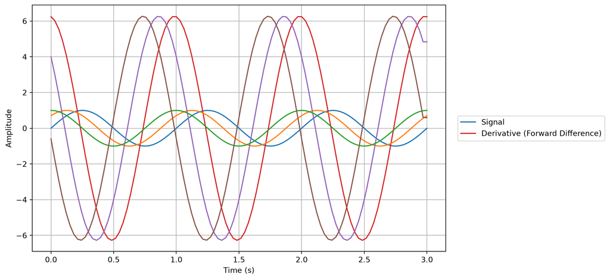

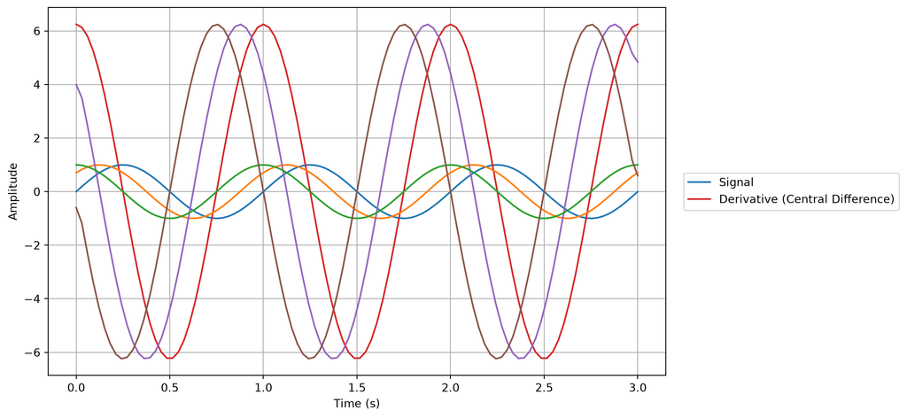

```python
d_forward = derivative_forward(signal, time)  # shape (N, 3)
d_central = derivative_central(signal, time)  # shape (N, 3)

#print(f"signal.shape    = {signal.shape}")
#print(f"d_forward.shape = {d_forward.shape}")
#print(f"d_central.shape = {d_central.shape}")

# Analytical derivative (see the first section above)
phases = np.array([0, phase_shift, 2 * phase_shift])  # one phase per axis
exact = 2 * np.pi * np.cos(2 * np.pi * time + phases)

# Compare on interior samples only, since the edge values are one-sided estimates
#print(f"max error, forward difference: {np.abs(d_forward - exact)[1:-1].max():.3f}")
#print(f"max error, central difference: {np.abs(d_central - exact)[1:-1].max():.3f}")

for name, d in [("Forward", d_forward), ("Central", d_central)]:
    plt.figure(figsize=(10, 6))  # one figure per method

    for i in range(3):  # loop over x, y, z
        plt.plot(time[:, 0], signal[:, i], color=f"C{i}", linewidth=1.5,
                 label="Signal" if i == 0 else None)  # C0, C1, C2: blue, orange, green
        plt.plot(time[:, 0], d[:, i], color=f"C{i + 3}", linewidth=1.5,
                 label=f"Derivative ({name} Difference)" if i == 0 else None)  # C3, C4, C5

    plt.xlabel("Time (s)")
    plt.ylabel("Amplitude")
    plt.legend(loc="center left", bbox_to_anchor=(1.02, 0.5))  # legend outside, like the reference
    plt.grid()
    plt.show()
```

# 4 Estimate the tangential speed of the signal

## 4.1 Tangential Velocity and Tangential Speed

Tangential velocity is the instantaneous linear velocity of an object moving along a circular or curved trajectory. It is a vector quantity, meaning that it has both a magnitude and a direction. The direction of the tangential velocity is tangent to the trajectory at each point.

Tangential speed is the magnitude of the tangential velocity. Therefore, unlike tangential velocity, it is a scalar quantity and does not contain directional information. (Strang & Herman, 2016)

For a movement described by a position vector $\mathbf{r}(t)$, the velocity is the time derivative of the position:

$$\mathbf{v}(t) = \frac{d\mathbf{r}(t)}{dt}.$$

The corresponding speed is the magnitude of this velocity:

$$v(t) = \|\mathbf{v}(t)\|.$$

Thus, tangential speed describes how fast the object moves along its trajectory, while tangential velocity also indicates the instantaneous direction of motion. (Ammon, 2017)

## 4.2 Tangential Speed Formula

The tangential speed of a movement is obtained from its tangential velocity by taking the magnitude of the velocity vector (Martin et al., 2018).

### 4.2.1 3D movement

For a 3D movement, the position can be represented by the vector:

$$\mathbf{r}(t) =
\begin{bmatrix}
x(t)\\
y(t)\\
z(t)
\end{bmatrix}.$$

The tangential velocity is the time derivative of the position:

$$\mathbf{v}(t)
=
\frac{d\mathbf{r}(t)}{dt}
=
\begin{bmatrix}
\frac{dx}{dt}\\
\frac{dy}{dt}\\
\frac{dz}{dt}
\end{bmatrix}.$$

Since tangential speed is the magnitude of the tangential velocity, its value at time $t$ is given by the Euclidean norm of the velocity vector:

$$v(t)
=
\|\mathbf{v}(t)\|
=
\sqrt{
\left(\frac{dx}{dt}\right)^2
+
\left(\frac{dy}{dt}\right)^2
+
\left(\frac{dz}{dt}\right)^2
}.$$

### 4.2.2 nD movement

This formula can be generalized to a movement described in $d$ dimensions. If the position is:

$$\mathbf{r}(t)
=
\begin{bmatrix}
x_1(t)\\
x_2(t)\\
\vdots\\
x_d(t)
\end{bmatrix},$$

then the velocity is:

$$\mathbf{v}(t)
=
\begin{bmatrix}
\frac{dx_1}{dt}\\
\frac{dx_2}{dt}\\
\vdots\\
\frac{dx_d}{dt}
\end{bmatrix}.$$

Therefore, the tangential speed is:

$$v(t)
=
\sqrt{
\sum_{j=1}^{d}
\left(\frac{dx_j}{dt}\right)^2
}.$$

Thus, regardless of the number of spatial dimensions, the tangential speed is obtained by taking the Euclidean norm of the velocity components at each time sample (Strang & Herman, 2016).

## 4.3 Tangential Speed Function

The tangential speed can be computed from a sampled movement by first estimating the velocity of each spatial dimension and then calculating the Euclidean norm of the velocity vector.

The inputs are provided in the following order:

- `signal`: a NumPy array containing the spatial coordinates. Samples are arranged along rows and spatial dimensions along columns.
- `time`: a NumPy array containing the measurement times, with one time value for each sample.

The `signal` is provided first because it represents the movement data from which the velocity is estimated, while `time` provides the temporal information needed to calculate the derivative.

For a signal with `N` samples and `d` spatial dimensions, the velocity has the shape `(N, d)`. The tangential speed is then obtained by calculating the Euclidean norm across the spatial dimensions. Therefore, the output is a one-dimensional NumPy array with `N` values, one tangential speed value for each time sample.

```python
def tangential_speed(signal, time):
    """
    Compute the tangential speed of a multidimensional movement.

    Parameters
    ----------
    signal : numpy.ndarray
        Position signal with samples over rows and
        spatial dimensions over columns.
    time : numpy.ndarray
        Time values corresponding to each sample.

    Returns
    -------
    numpy.ndarray
        Tangential speed for each time sample.
    """

    velocity = derivative_central(signal, time)
    speed = np.linalg.norm(velocity, axis=1)

    return speed
```

## 4.4 Function Tests

We test the function using simple sampled signals for which the expected tangential speed can be calculated analytically.

For each test, the expected velocity is first determined from the change in position divided by the change in time. The expected tangential speed is then calculated as the Euclidean norm of the velocity vector.

The tests cover signals with 1, 2, 3, and nD spatial dimensions.

### 4.4.1 1D signal test

For the 1D test, the position increases by 1 unit for each time interval of 1 unit. Therefore, the velocity is 1 unit per unit of time, and the expected tangential speed is:

$$v = \sqrt{1^2} = 1.$$

```python
# Test 1: 1D movement

time_test = np.array([0, 1, 2, 3])
signal_1d = np.array([[0], [1], [2], [3]])

speed_1d = tangential_speed(signal_1d, time_test)

expected_1d = np.array([1, 1, 1, 1])

assert np.allclose(speed_1d, expected_1d)

speed_1d
```

```
array([1., 1., 1., 1.])
```

We created a simple 1D signal where the position increases linearly with time. The expected tangential speed is constant at 1 unit per unit of time.

### 4.4.2 2D signal test

For the 2D test, the position increases by 1 unit per time interval in the first dimension and by 2 units per time interval in the second dimension.

Therefore, the expected tangential speed is:

$$v = \sqrt{1^2 + 2^2} = \sqrt{5}.$$

```python
# Test 2: 2D movement

time_test = np.array([0, 1, 2, 3])

signal_2d = np.array([
    [0, 0],
    [1, 2],
    [2, 4],
    [3, 6]
])

speed_2d = tangential_speed(signal_2d, time_test)

expected_2d = np.array([
    np.sqrt(5),
    np.sqrt(5),
    np.sqrt(5),
    np.sqrt(5)
])

assert np.allclose(speed_2d, expected_2d)

speed_2d
```

```
array([2.23606798, 2.23606798, 2.23606798, 2.23606798])
```

We created a simple 2D signal where the position increases by 1 unit per time interval in the first dimension and by 2 units per time interval in the second dimension. The expected tangential speed is constant at $\sqrt{5}$, approximately 2.236 units per unit of time. This explains the output of the test.

### 4.4.3 3D signal test

For the 3D test, the position increases by 1 unit per time interval in the first dimension, 2 units in the second dimension, and 2 units in the third dimension.

Therefore, the expected tangential speed is:

$$v = \sqrt{1^2 + 2^2 + 2^2} = 3.$$

```python
# Test 3: 3D movement

time_test = np.array([0, 1, 2, 3])

signal_3d = np.array([
    [0, 0, 0],
    [1, 2, 2],
    [2, 4, 4],
    [3, 6, 6]
])

speed_3d = tangential_speed(signal_3d, time_test)

expected_3d = np.array([3, 3, 3, 3])

assert np.allclose(speed_3d, expected_3d)

speed_3d
```

```
array([3., 3., 3., 3.])
```

We created a simple 3D signal where the position increases by 1 unit per time interval in the first dimension and by 2 units per time interval in the second and third dimensions. The expected tangential speed is constant at 3 units per unit of time.

### 4.4.4 nD signal test

We tested a 5D signal to verify that the function works with more than three spatial dimensions. The position changes by 1, 2, 3, 4, and 5 units per time interval in the five dimensions. The expected tangential speed is constant at $\sqrt{55}$, approximately 7.416 units per unit of time.

Therefore, the expected tangential speed is:
$$v = \sqrt{1^2 + 2^2 + 3^2 + 4^2 + 5^2}
= \sqrt{55}
\approx 7.416.$$

```python
# Test 4: nD movement (5D)

time_test = np.array([0, 1, 2, 3])

signal_5d = np.array([
    [0, 0, 0, 0, 0],
    [1, 2, 3, 4, 5],
    [2, 4, 6, 8, 10],
    [3, 6, 9, 12, 15]
])

speed_5d = tangential_speed(signal_5d, time_test)

expected_5d = np.array([
    np.sqrt(55),
    np.sqrt(55),
    np.sqrt(55),
    np.sqrt(55)
])

assert np.allclose(speed_5d, expected_5d)

speed_5d
```

```
array([7.41619849, 7.41619849, 7.41619849, 7.41619849])
```

The tests for 1D, 2D, 3D, and nD signals all produced the expected results. The `assert` statements confirmed that the `tangential_speed()` function works correctly for signals with different numbers of dimensions.

# 5 Create an interactive plot with the Plotly library

## 5.1 Interactive Plot

The objective of this section is to visualize a movement signal and its tangential speed using the Plotly library. Plotly creates interactive plots that allow us to inspect the data, zoom in and out, and explore the relationship between position and tangential speed.

```python
# Calculate tangential speed using the existing function
speed = tangential_speed(signal, time)

# Create an interactive figure
fig = go.Figure()

# Add the three position components
fig.add_trace(
    go.Scatter(
        x=time[:, 0],
        y=signal[:, 0],
        mode="lines",
        name="X position"
    )
)

fig.add_trace(
    go.Scatter(
        x=time[:, 0],
        y=signal[:, 1],
        mode="lines",
        name="Y position"
    )
)

fig.add_trace(
    go.Scatter(
        x=time[:, 0],
        y=signal[:, 2],
        mode="lines",
        name="Z position"
    )
)

# Add tangential speed
fig.add_trace(
    go.Scatter(
        x=time[:, 0],
        y=speed,
        mode="lines",
        name="Tangential speed"
    )
)

# Configure the interactive plot
fig.update_layout(
    title="Position Signal and Tangential Speed",
    xaxis_title="Time (s)",
    yaxis_title="Amplitude (m) / Velocity (m/s)",
    hovermode="x unified"
)

fig.show()
```

[interactive chart not shown]

### 5.1.1 Interpretation

The interactive Plotly figure displays the three spatial components of the movement signal (X, Y, and Z) and the tangential speed as functions of time. The interactive controls allow us to inspect specific time intervals, zoom in and out, and examine the values using hover information. This makes it easier to explore changes in the movement signal and its tangential speed over time.

# 6 References

Ammon, C. (2017, December 1). *Tangential velocity - vs - tangential speed*. Physics Stack Exchange. https://physics.stackexchange.com/questions/371973/tangential-velocity-vs-tangential-speed

Kong, Q., Siauw, T., & Bayen, A. (2020). *Python Programming and Numerical Methods: A Guide for Engineers and Scientists*, Chapter 20.2, “Finite Difference Approximating Derivatives”. https://pythonnumericalmethods.studentorg.berkeley.edu/notebooks/chapter20.02-Finite-Difference-Approximating-Derivatives.html

Martin, R. D., Neary, E., Rinaldo, J., & Woodman, O. (2018). Uniform circular motion. Physics LibreTexts. https://phys.libretexts.org/Bookshelves/University_Physics/Book%3A_Introductory_Physics_-*Building_Models_to_Describe_Our_World*%28Martin_Neary_Rinaldo_and_Woodman%29/06%3A_Applying_Newtons_Laws/6.03%3A_Uniform_circular_motion

Strang, G., & Herman, E. J. (2016). *Calculus volume 3*. OpenStax. https://openstax.org/books/calculus-volume-3/pages/3-4-motion-in-space